# Week 5: Visualization in Python

- Basic Guidelines for good visualizations
- Introduction to Matplotlib
  - Installation
  - Types of inputs to plotting functions
  - Components of a Matplotlib graph.
  - Pyplot
  - Figures and axes
    - Method-1
    - Method-2
  - Customization
    - Customization example
    - Colors
    - Linewidths, linestyles, and markersizes
    - Axes labels and text
  - Subplots
- Introduction to Seaborn
  - Installation
  - Getting started
  - Customization
    - Matplotlib inheritance
    - Styles and color palettes
  - Example gallery
- References

# Basic Guidelines for good visualizations

**When making professional level plots, it is very important to adhere to the following guidelines (at a minimum).**

- 1) **INCLUDE DESCRIPTIVE LABELS AND UNITS:**
  - Always include a **descriptive label** and **units** on any axis-label that you create!
  - A number without units is often meaningless and frustrating for the reader
  - For example, if you plot the price of the S&P 500 along the y-axis, then it is unacceptable to just label it "price".
    - If an outsider looks at your graph they will think, "what does price mean?"
    - Is "price" the price of shoes at walmart?
    - Is "price" the average price of a motorcycle at your local used car dealership?
    - What are the units of this "price" metric, US dollars, Russian rubles, French francs, British pounds, Chinese Yuan?
    - How can we better communicate this metric?
      - label="price" $\implies$ VERY BAD
      - label="The instantaneous price of the S&P-500 stock index (US dollars)" $\implies$ GOOD
- 2) **USE LARGE FONTS:** Always use relatively large font sizes for your axis-labels, tic-marks, and other plot annotations.
  - why is this important?
    - First off, it makes your plots more accessible to people who have trouble seeing small text.
    - Second, often your plots will be used in presentations. Therefore, your plots need to be legible, even from the back of the room.
  - fontsize=12 $\implies$ BAD
  - fontsize=20 $\implies$ GOOD
  - Note: Don't take it too far by making your axis labels comically large.
- 3) **DONT OVERPLOT:** Over plotting is when you try to cram too much information into a single plot.
  - Usually the result is very hard for the reader to digest.
  - Typically it is best to keep your graphics relatively simple, conveying only 1 or 2 messages.
- 4) **ALWAYS HAVE A MESSAGE:** Never include "plots for plots sake".
  - Graphics are almost always part of some larger narrative.
  - If a particular plot doesn't strengthen the narrative, and add meaningful value, then it should not be included.
- 5) **NEVER HAVE OVERLAPPING TEXT IN A PLOT:**
  - This is just sloppy and unprofessional, you should always avoid it.

**Failure to adhere to these guidelines will consistently lose you points in any class you take in the DSAN program**.

# Introduction to Matplotlib

- Matplotlib, short for "*Math Plotting Library*" (MPL), is by far the most common plotting library (i.e. package) in Python.
- Matplotlib is a comprehensive library for creating static, animated, or interactive visualizations in Python.
- Common use cases for Matplotlib include
  - Create publication quality plots.
  - Make interactive figures that can zoom, pan, update.
  - Customize visual style and layout.
  - Export to many file formats .
  - Embed in JupyterLab and Graphical User Interfaces.
  - Use a rich array of third-party packages built on Matplotlib.
- **IMPORTANT NOTE:**
  - MPL is a very flexible and complex library, we will only be covering the basics and "scratching the surface" in this tutorial.
  - For a more detailed look at Matplotlib, please visit the tutorials on their website at the following link
    - https://matplotlib.org/stable/tutorials/index.html
  - For various advanced examples of MPL, see the following link
    - https://matplotlib.org/stable/gallery/index.html

## Installation

Matplotlib can be installed using either pip or conda by running the following commands from the command line.

- python -m pip install matplotlib
- conda install matplotlib

## Types of inputs to plotting functions

- All plotting functions expect np.array or np.ma.masked_array as input.
- Classes that are 'array-like' such as pandas data objects and np.matrix may or may not work as intended.
- It is best to convert these to np.array objects prior to plotting.

## Components of a Matplotlib graph.

Run the following cell to see the various key components of a MPL figure

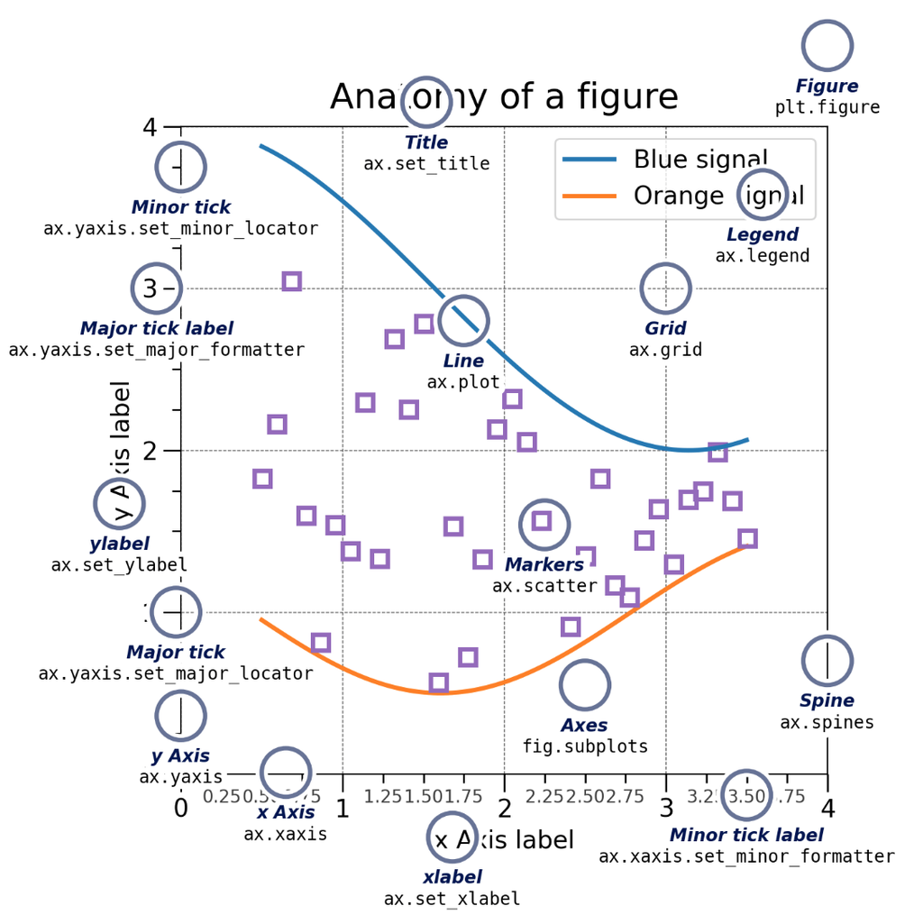

```python
%matplotlib inline
from IPython.display import Image
Image('images/figure-1.png', width = 600, height = 600)
```

## Pyplot

- matplotlib.pyplot is a collection of functions that make matplotlib work like MATLAB.
- Each pyplot function makes some change to a figure: e.g.,
  - creates a figure, creates a plotting area in a figure, plots some lines in a plotting area, decorates the plot with labels, etc.
- In matplotlib.pyplot various states are preserved across function calls.
  - This means it keeps track of things like the current figure and plotting area
  - The plotting functions are directed to the current axes

## Figures and axes

In matplotlib there are two important object types, the figure object and the axes object.

- This sometimes leads to confusion, because you will see code that uses axes objects commands and sometimes not.
- So what is the difference between these two objects?
- **Figures** (canvas)
  - Think of figures as the blank canvas (or paper) on which you are going to put your plots (i.e. the whole figure).
  - The Figure keeps track of all the child Axes, a group of attributes (titles, figure legends, colorbars, etc), and even nested subfigures.
  - It is often convenient to create the Axes together with the Figure, but you can also manually add Axes later on.
  - When you modify the figure attribute you are modifying the canvas rather than the subplots
- **Axes** (individual plots)
  - Think of axes as the individual plots that go on the paper.
    - Each figure (canvas) can contain one or more Axes.
      - Just like with pen and paper, you can put one plot on the paper or many (i.e. subplots)
    - The axes are areas where points can be specified in terms of x-y coordinate system
      - (or theta-r in a polar plot, x-y-z in a 3D plot, etc).
    - The simplest way of creating a Figure with an Axes is using pyplot.subplots.
    - We can then use Axes.plot to draw some data on the Axes:
    - The Axes class and its member functions are the primary entry point to working with the MLP interface
      - They have most of the plotting methods defined on them (e.g. ax.plot())

The following figure exemplifies the difference between the two types of objects.

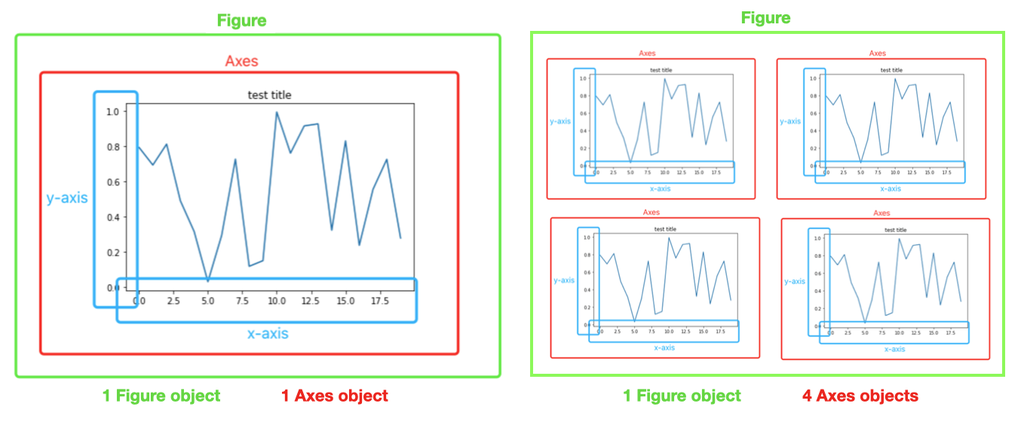

```python
%matplotlib inline
from IPython.display import Image
Image('images/figure-2.png', width = 1000, height = 500)
```

**Because of these two object types, there are essentially two ways to use Matplotlib:**

- Method-1) Rely on pyplot to automatically create and manage the Figures and Axes, and use pyplot functions for plotting.
- Method-2) Explicitly create Figures and Axes, and call methods on them (i.e. the "object-oriented (OO) style").

### Method-1

- In this case we don't explicitly define the figure and axes object
- However, the code implicitly defines them in the background

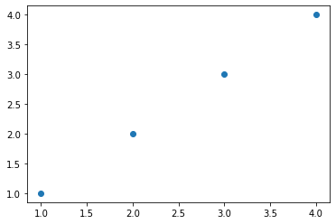

```python
import matplotlib.pyplot as plt
import numpy as np

#DEFINE DATA
x=[1, 2, 3, 4]
y=[1, 2, 3, 4]

#PLOT
plt.plot(x,y,'o') # 'o' makes a scatterplot or point plot
plt.show()
```

**IMPORTANT NOTE:**

- When using a Jupiter notebook (.ipynb), you do not need to explicitly tell the code to render the plot by using the "plt.show()" command.
- However, when using standard python (.py), you do need to include the command, otherwise the plot will not render.
  - Therefore, we include the command below for completeness sake
- The same is true regarding printing to the screen.
  - A standard python code (.py) will not print, unless the print() command is explicitly called.

For completeness sake, we will frequently repeat the import commands, so that the code chunks are self-contained.

**Basic customization**

- We can still do some basic customization, even though we did not explicitly define the figure and axes objects.
- These commands are modifying attributes of the implicitly defined figure object.

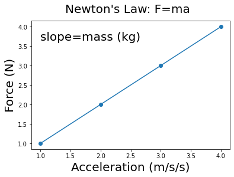

```python
import matplotlib.pyplot as plt

#DEFINE DATA
x=[1, 2, 3, 4]
y=[1, 2, 3, 4]

#PLOT
plt.plot(x,y,'-o') # '-o' makes plots points and a line

#SET FIGURE LABELS AND TITLE
FS=20
plt.suptitle("Newton's Law: F=ma", fontsize=FS)
plt.xlabel('Acceleration (m/s/s)', fontsize=FS)
plt.ylabel('Force (N)', fontsize=FS)
#TUPLE SPECIFIES WHERE TO PUT ANNOTATION
plt.annotate("slope=mass (kg)", (1,3.65), fontsize=FS)
plt.show()
```

### Method-2

- In this case we explicitly define both a figure object and an axes object.
- This method is preferred because it generalizes to the case of subplots, as we will see later.

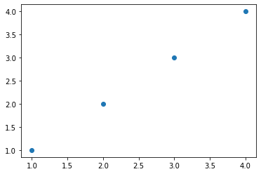

```python
import matplotlib.pyplot as plt
import numpy as np

#DEFINE DATA
x=[1, 2, 3, 4]
y=[1, 2, 3, 4]

#DEFINE OBJECTS
fig, ax = plt.subplots()

#PLOT
ax.plot(x,y,'o')
plt.show()
```

**Basic customization**

- Just as with method-1, we can do various forms of customization.
- However notice that some of the commands are different, since we are acting on the axis object.

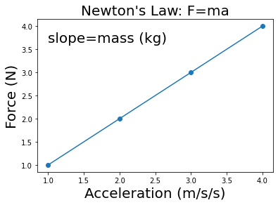

```python
import matplotlib.pyplot as plt
import numpy as np

#DEFINE DATA
x=[1, 2, 3, 4]
y=[1, 2, 3, 4]

#DEFINE OBJECTS
fig, ax = plt.subplots()

#PLOT
ax.plot(x,y,'-o')

#CUSTOMIZE
FS=20
ax.set_title("Newton's Law: F=ma", fontsize=FS)
ax.set_xlabel('Acceleration (m/s/s)', fontsize=FS)
ax.set_ylabel('Force (N)', fontsize=FS)
ax.annotate("slope=mass (kg)", (1,3.65), fontsize=FS)
plt.show()
```

## Customization

Typically the default properties of plots are un-acceptable for professional level presentations.

This is because, the labels are not very intuitive, lack units, and have font that is too small.

Therefore, we often want to modify them to generate higher-quality visualizations.

**The default parameters of MPL are stored in an object called rcParams which is similar to a dictionary**

**Therefore, there are essentially four ways to customize Matplotlib:**

- 1) Setting rcParams at runtime.
- 2) Using style sheets.
- 3) Changing your matplotlibrc file.
- 4) Manually modifying attributes of your plot when you create it
- We will discuss methods 1 and 4 below, more details about customization can be found at the following link
  - https://matplotlib.org/3.5.0/tutorials/introductory/customizing.html

**NOTE**: Setting rcParams at runtime takes precedence over style sheets, style sheets take precedence over matplotlibrc files.

You can print the defaults in the rcParams object, as shown below.

```python
print(plt.rcParams)
```

```
_internal.classic_mode: False
agg.path.chunksize: 0
animation.bitrate: -1
animation.codec: h264
animation.convert_args: []
animation.convert_path: convert
animation.embed_limit: 20.0
animation.ffmpeg_args: []
animation.ffmpeg_path: ffmpeg
animation.frame_format: png
animation.html: none
animation.writer: ffmpeg
axes.autolimit_mode: data
axes.axisbelow: line
axes.edgecolor: black
axes.facecolor: white
axes.formatter.limits: [-5, 6]
axes.formatter.min_exponent: 0
axes.formatter.offset_threshold: 4
axes.formatter.use_locale: False
axes.formatter.use_mathtext: False
axes.formatter.useoffset: True
axes.grid: False
axes.grid.axis: both
axes.grid.which: major
axes.labelcolor: black
axes.labelpad: 4.0
axes.labelsize: medium
axes.labelweight: normal
axes.linewidth: 0.8
axes.prop_cycle: cycler('color', ['#1f77b4', '#ff7f0e', '#2ca02c', '#d62728', '#9467bd', '#8c564b', '#e377c2', '#7f7f7f', '#bcbd22', '#17becf'])
axes.spines.bottom: True
axes.spines.left: True
axes.spines.right: True
axes.spines.top: True
axes.titlecolor: auto
axes.titlelocation: center
axes.titlepad: 6.0
axes.titlesize: large
axes.titleweight: normal
```

[output cut: 249 more lines]

```
ytick.labelright: False
ytick.labelsize: medium
ytick.left: True
ytick.major.left: True
ytick.major.pad: 3.5
ytick.major.right: True
ytick.major.size: 3.5
ytick.major.width: 0.8
ytick.minor.left: True
ytick.minor.pad: 3.4
ytick.minor.right: True
ytick.minor.size: 2.0
ytick.minor.visible: False
ytick.minor.width: 0.6
ytick.right: False
```

```python
# OR YOU CAN PRINT INDIVIDUAL DEFAULT ATTRIBUTES
print(plt.rcParams["figure.figsize"])
```

```
[6.0, 4.0]
```

```python
# YOU CAN ALSO MODIFY THESE ATTRIBUTES
plt.rcParams["figure.figsize"]= (10,10)     # change the default figure size to a 10in x 10in resolution
print(plt.rcParams["figure.figsize"])
```

```
[10.0, 10.0]
```

This modification will effect all future plots, unless we change it back.

Or until we restart the python kernel, e.g. by reopening the .ipynb file or re-running the .py file, which will restore the un-modified defaults.

```python
#RESET TO ORIGINAL DEFAULTS
plt.rcParams["figure.figsize"]= (6,4)
print(plt.rcParams["figure.figsize"])
```

```
[6.0, 4.0]
```

### Customization example

The following example shows various ways to manually modify attributes of your plot when you create it (i.e. method-4).

These modifications do not change the MPL defaults in rcParams.

These customization options can be used to make a professional looking graph.

**IMPORTANT NOTE**: At the bottom of the code, there are various commands that can print the plot to a file using different file formats.

[figure not shown]

```python
import matplotlib.pyplot as plt
import numpy as np

#GENERATE DATA
N=500   #number of data points
x=np.linspace(-45,45.0, N);
ye=x*x*np.sin(x) #exact
y=ye+np.random.normal(0, 200, N) #add noise

#FONT SIZE
FS=22

#DEFINE FIG+AX OBJECTS
fig, ax = plt.subplots()
#https://www.canva.com/colors/color-wheel/
ax.plot(x,y,'o',color='#FF0012', markersize=16, label='Data')
ax.plot(x,ye, color='#0012FF'  ,linewidth=6, label='Ground truth')
ax.plot(x,ye,color='#12FF00'   , linewidth=1, linestyle='dashed')

#SET LEGEND
ax.legend(fontsize=FS)

#SET FIGURE SIZE
fig.set_size_inches(10, 10)

#FIGURE TITLE
fig.suptitle('Decaying harmonic oscillations', fontsize=24)

#AXIS LABELS
ax.set_xlabel('Time (ps)', fontsize=FS)
ax.set_ylabel('Amplitude (cm)', fontsize=FS)

# #X-Y PLOT RANGE
ax.set_xlim([-40,0])
ax.set_ylim([-1750,1750])

#AXIS TIC VALUES
ax.set_xticks([-40,-30,-20,-10,0],fontsize=20)
ax.set_yticks([-2000,-1000,0,1000,2000],fontsize=20)

#CONTROL AXIS TICK FORMAT
ax.yaxis.set_major_formatter(plt.FormatStrFormatter('%4.2f'))
ax.xaxis.set_major_formatter(plt.FormatStrFormatter('%.1f'))

#AXIS TIC FONT SIZE
ax.tick_params(axis='both', which='major', labelsize=FS)
ax.tick_params(axis='both', which='minor', labelsize=FS)

# #SAVE IMAGES TO A FILE
fig.savefig('plot-1.png', bbox_inches='tight')
# f.savefig("plot-1.pdf", bbox_inches='tight')
# f.savefig("plot-1.eps", bbox_inches='tight')

#RENDER AND SHOW IMAGE
plt.show()
```

### Colors

- Generally, colors are referenced in the computer using a six digit hex code.
  - For example,
    - black=000000
    - white=FFFFFF
    - red=FF0000
    - blue=0000FF
    - green=00FF00
  - To explore different text codes visit the following website
    - https://htmlcolorcodes.com/color-picker/
  - Matplotlib has a very flexible array of colors that are accepted for most Artists; see the colors tutorial for a list of specifications.
  - Some Artists will take multiple colors. i.e. for a scatter plot, the edge of the markers can be different colors from the interior:

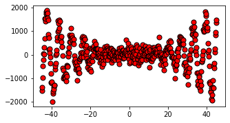

```python
fig, ax = plt.subplots(figsize=(5, 2.7))
ax.scatter(x, y, s=50, facecolor='#FF0000', edgecolor='#000000');
```

There are also various color palettes included with MPL. More information about color palettes be found at the following link

- https://matplotlib.org/3.5.0/tutorials/colors/colormaps.html

### Linewidths, linestyles, and markersizes

Line widths are typically in typographic points $(1 pt = \frac{1}{72}inch)$ and available for Artists that have stroked lines. Similarly, stroked lines can have a linestyle. See the linestyles example.

Marker size depends on the method being used. plot specifies markersize in points, and is generally the "diameter" or width of the marker. scatter specifies markersize as approximately proportional to the visual area of the marker. There is an array of markerstyles available as string codes (see markers), or users can define their own MarkerStyle (see Marker reference):

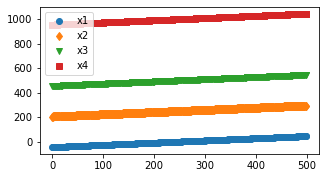

```python
fig, ax = plt.subplots(figsize=(5, 2.7))
ax.plot(x, 'o', label='x1')
ax.plot(x+250, 'd', label='x2')
ax.plot(x+500, 'v', label='x3')
ax.plot(x+1000, 's', label='x4')
ax.legend();
```

### Axes labels and text

`set_xlabel`, `set_ylabel`, and `set_title` are used to add text in the indicated locations (see Text in Matplotlib Plots for more discussion). Text can also be directly added to plots using text:

All of the text functions return a matplotlib.text.Text instance. Just as with lines above, you can customize the properties by passing keyword arguments into the text functions:

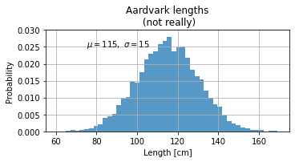

```python
mu, sigma = 115, 15
x = mu + sigma * np.random.randn(10000)
fig, ax = plt.subplots(figsize=(5, 2.7), layout='constrained')
# the histogram of the data
n, bins, patches = ax.hist(x, 50, density=1, facecolor='C0', alpha=0.75)

ax.set_xlabel('Length [cm]')
ax.set_ylabel('Probability')
ax.set_title('Aardvark lengths\n (not really)')
ax.text(75, .025, r'$\mu=115,\ \sigma=15$')
ax.axis([55, 175, 0, 0.03])      # sets x and y limits of the figure axes
ax.grid(True);                   # add gridlines to plot
```

## Subplots

- If we want to include multiple subplots in one figure (known as faceting), then we need to define multiple axes objects.
- The individual axes objects can be modified using the standard indexing formalism discussed for lists in a previous lesson.
- The following examples demonstrates the generation of subplots.
  - https://matplotlib.org/stable/gallery/subplots_axes_and_figures/subplots_demo.html
  - https://towardsdatascience.com/what-are-the-plt-and-ax-in-matplotlib-exactly-d2cf4bf164a9

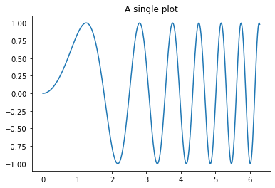

```python
import matplotlib.pyplot as plt
import numpy as np

# Some example data to display
x = np.linspace(0, 2 * np.pi, 400)
y = np.sin(x ** 2)

#EXAMPLE-1
fig, ax = plt.subplots()
ax.plot(x, y)
ax.set_title('A single plot')
```

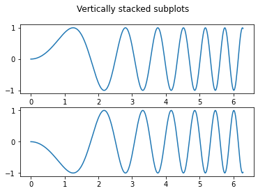

```python
#EXAMPLE-2
fig, axs = plt.subplots(2)
fig.suptitle('Vertically stacked subplots')
axs[0].plot(x, y)
axs[1].plot(x, -y)
```

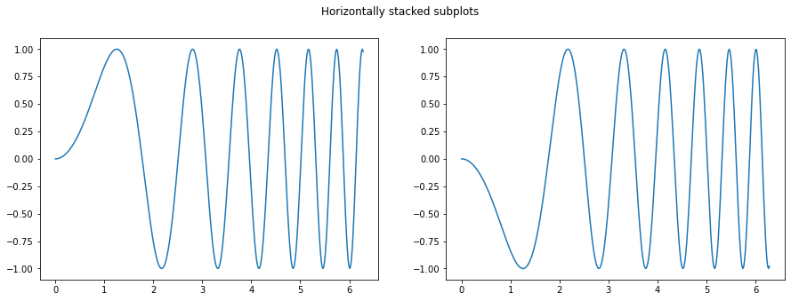

```python
#EXAMPLE-3

fig, (ax1, ax2) = plt.subplots(1, 2)
fig.suptitle('Horizontally stacked subplots')
ax1.plot(x, y)
ax2.plot(x, -y)

#INCREASE FIGURE SIZE
fig.set_size_inches(15, 5)
plt.show()
```

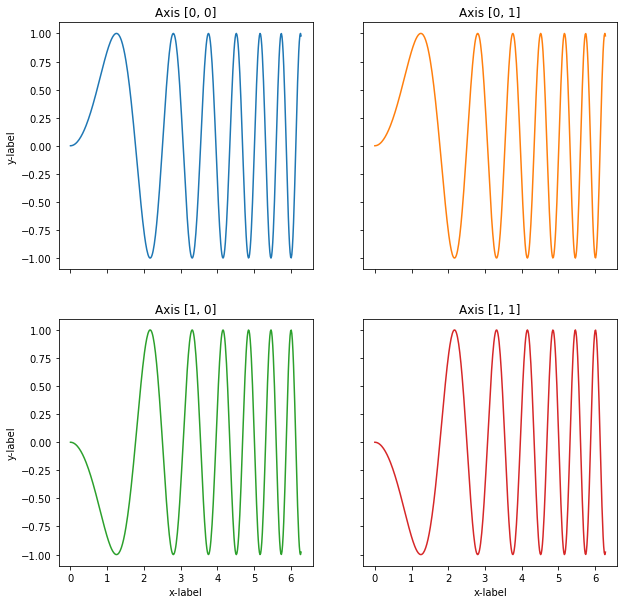

```python
#EXAMPLE-4
fig, axs = plt.subplots(2, 2)
axs[0, 0].plot(x, y)
axs[0, 0].set_title('Axis [0, 0]')
axs[0, 1].plot(x, y, 'tab:orange')
axs[0, 1].set_title('Axis [0, 1]')
axs[1, 0].plot(x, -y, 'tab:green')
axs[1, 0].set_title('Axis [1, 0]')
axs[1, 1].plot(x, -y, 'tab:red')
axs[1, 1].set_title('Axis [1, 1]')

for ax in axs.flat:
    ax.set(xlabel='x-label', ylabel='y-label')

# Hide x labels and tick labels for top plots and y ticks for right plots.
for ax in axs.flat:
    ax.label_outer()

#INCREASE FIGURE SIZE
fig.set_size_inches(10, 10)
plt.show()
```

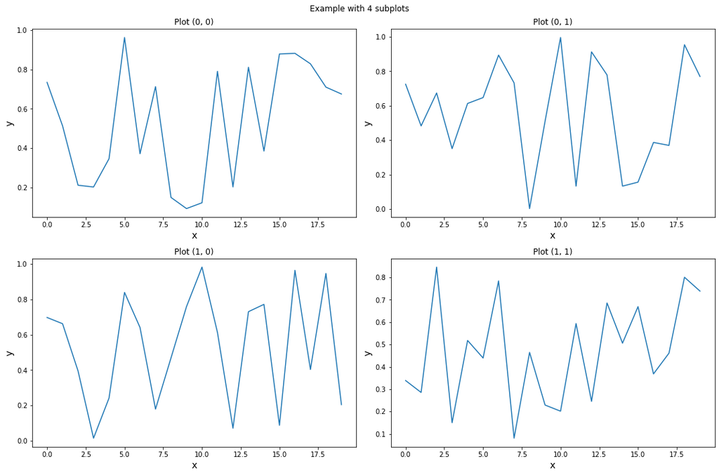

```python
#EXAMPLE-5
import matplotlib.pyplot as plt
import numpy as np

n_rows = 2
n_cols = 2
#INITIALIZE
fig, axes = plt.subplots(n_rows, n_cols)

#INCREASE FIGURE SIZE
fig.set_size_inches(15, 10)

#POPULATE ROW AND COLUMN AXES OBJECT
for row_num in range(n_rows):
    for col_num in range(n_cols):
        #AXES (CELL) ATTRIBUTES
        ax_ij = axes[row_num][col_num]
        ax_ij.plot(np.random.rand(20))
        ax_ij.set_title(f'Plot ({row_num}, {col_num})')
        ax_ij.set_xlabel('x', fontsize=14)
        ax_ij.set_ylabel('y', fontsize=14)
        # ax_ij.legend(fontsize=12)

#FIGURE ATTRIBUTES
fig.suptitle('Example with 4 subplots')
fig.tight_layout()
plt.show()
```

# Introduction to Seaborn

Seaborn is a library for making statistical graphics in Python.

It builds on top of matplotlib and integrates closely with pandas data structures.

It provides a high-level interface for drawing attractive and informative statistical graphics.

Its plotting functions operate on dataframes and arrays containing whole datasets and internally perform the necessary semantic mapping and statistical aggregation to produce informative plots.

Its dataset-oriented, declarative API lets you focus on what the different elements of your plots mean, rather than on the details of how to draw them.

For more see: https://seaborn.pydata.org/

## Installation

Seaborn can be installed using either pip or Conda by running the following commands from the command line or Conda powershell.

- python -m pip install seaborn
- conda install seaborn

## Getting started

Seaborn is typically imported under the alias "sns"

```python
# IMPORT SEABORN
import seaborn as sns
import matplotlib.pyplot as plt
```

Seaborn includes various sample data sets which can be used for educational purposes.

These are obtained using the "seaborn.load_dataset()" function which returns a dataset as a pandas data-frame.

The data is pulled from an online repository, therefore the function requires internet access to work.

A list of the available data sets can be found at the following link: https://github.com/mwaskom/seaborn-data

In the following examples, we will use the "tips" dataset which contains both continuous and categorical features.

It has 244 samples with seven features per sample, as showing in the following code cell.

```python
# LOAD THE DATA-FRAME (REQUIRES INTERNET)
df = sns.load_dataset("tips")
print(df)
```

```
     total_bill   tip     sex smoker   day    time  size
0         16.99  1.01  Female     No   Sun  Dinner     2
1         10.34  1.66    Male     No   Sun  Dinner     3
2         21.01  3.50    Male     No   Sun  Dinner     3
3         23.68  3.31    Male     No   Sun  Dinner     2
4         24.59  3.61  Female     No   Sun  Dinner     4
..          ...   ...     ...    ...   ...     ...   ...
239       29.03  5.92    Male     No   Sat  Dinner     3
240       27.18  2.00  Female    Yes   Sat  Dinner     2
241       22.67  2.00    Male    Yes   Sat  Dinner     2
242       17.82  1.75    Male     No   Sat  Dinner     2
243       18.78  3.00  Female     No  Thur  Dinner     2

[244 rows x 7 columns]
```

Seaborn has many different plotting commands. However, typically the syntax of the various commands is similar.

Below is a simple "scatterplot" example, where we plot two continuous numerical variables, one on the x-axis and the other on the y-axis.

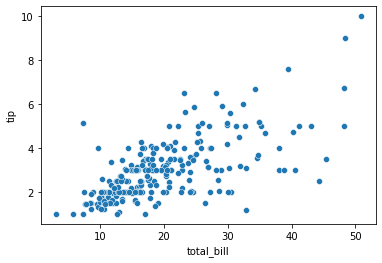

```python
sns.scatterplot(data=df, x="total_bill", y="tip")
```

In data visualization, the term "encoding" describes the process of representing the variation in some numerical variable, either continuous or categorical, through aesthetic properties of the graph, such as size, shape, position, color, etc.

`Seaborn` makes encoding either continuous or categorical variables very easy.

The following is a list of some common encoding options in Seaborn.

However, different Seaborn commands have slightly different syntax.

Therefore they may require further googling to figure out the exact parameters.

- data: "dataframe you want to plot"
- x: "column of dataframe to use for x-axis"
- y: "column of dataframe to use for y-axis"
- col: "subplot option"
  - "col" stands for a column. By specifying a categorical variable, Seaborn will subdivide the dataset into the respective groups and plot each group in a subplot (see below)
- hue: "color encoding"
- style: "marker encoding"
- size: "size encoding'

In the previous example, we represented the continuous variables "tip" and "total_bill" using positional encodings along the x and y axis.

We can include additional information by specifying additional encodings, such as in the following example.

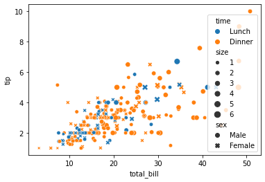

```python
sns.scatterplot(data=df, x="total_bill", y="tip",size="size",hue="time", style="sex")
```

Notice that Seaborn automatically infers whether the variable is continuous or categorical, and then applies a logical encoding choice accordingly.

In the previous example the color encoding took on two distinct colors, because "time" is a binary categorical variable (Lunch or dinner).

However, in the following example the color is encoded in a continuously varying fashion, since "tip" is a continuous numeric variable.

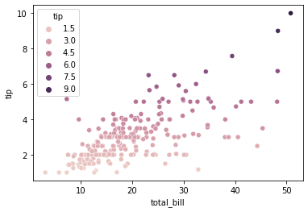

```python
sns.scatterplot(data=df, x="total_bill", y="tip",hue="tip")
```

## Customization

### Matplotlib inheritance

Seaborn is built on top of Matplotlib. Therefore, depending on the plotting command, it will return either a Matplotlib axes or figure object.

You can determine what is returned using the Python type() function

```
<class 'matplotlib.axes._subplots.AxesSubplot'>
```

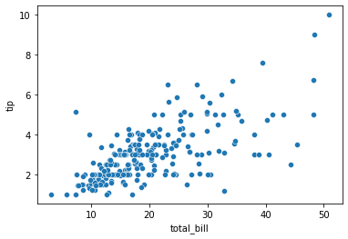

```python
print(type(sns.scatterplot(data=df, x="total_bill", y="tip")))
```

Notice, that the sns.scatterplot() function returns a MPL axes object. Therefore, we can use various MatplotLib axes commands to modify the Seaborn figure.

For example, in the next example we increase the figure (canvas) size by changing the MPL defaults in the rcParams dictionary.

Seaborn inherits various defaults from MPL, so this change will remain unless we change it back, or until you restart the python kernel, which will restore the un-modified defaults.

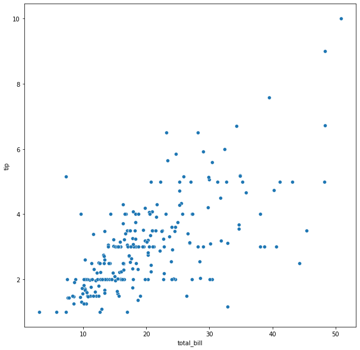

```python
import matplotlib.pyplot as plt
plt.rcParams["figure.figsize"] = (10,10)
sns.scatterplot(data=df, x="total_bill", y="tip")
```

Typically the default axis-labels are un-acceptable for professional level presentations and plots. Since they are not very intelligible, lack units, and have font that is too small.

Therefore, we often want to modify them and increase the font size.

The following example compares a plot generated using the Seaborn defaults with one that is customized.

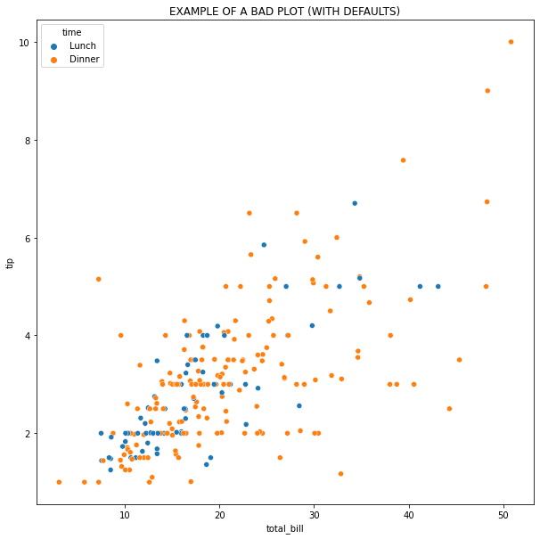

```python
ax=sns.scatterplot(data=df, x="total_bill", y="tip", hue="time")
ax.set_title("EXAMPLE OF A BAD PLOT (WITH DEFAULTS)")
```

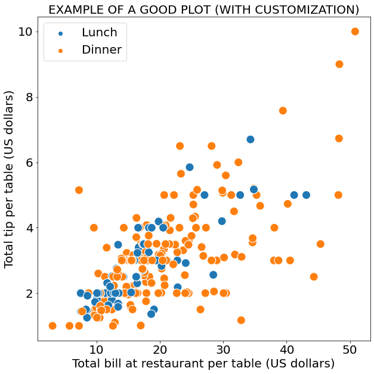

```python
#NOTICE THAT "s" CONTROLS THE MARKER SIZE
ax=sns.scatterplot(data=df, x="total_bill", y="tip", s=200, hue="time")

ax.set_title("EXAMPLE OF A GOOD PLOT (WITH CUSTOMIZATION)",fontsize=20)

#LEGEND FONT SIZE
ax.legend(fontsize=20)

#AXIS LABELS AND FONT SIZE
ax.set_xlabel('Total bill at restaurant per table (US dollars)', fontsize=20)
ax.set_ylabel('Total tip per table (US dollars)', fontsize=20)

#AXIS TIC FONT SIZE
ax.tick_params(axis='both', which='major', labelsize=20)
ax.tick_params(axis='both', which='minor', labelsize=20)
```

In some cases, Seaborn will return an object which is not a MLP axes or figure object.

```
<class 'seaborn.axisgrid.FacetGrid'>
```

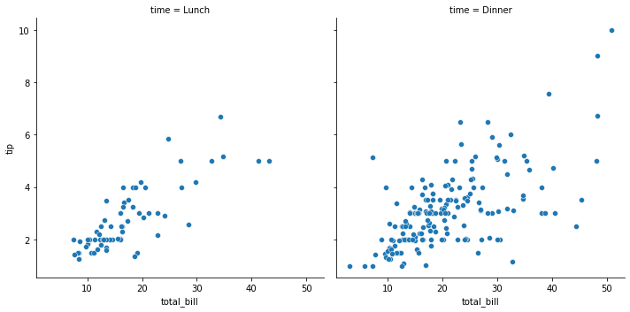

```python
my_plot=sns.relplot(
data=df,
x="total_bill",
y="tip",
col="time"
)
#NOTICE THE TYPES IS <class 'seaborn.axisgrid.FacetGrid'> NOT A MPL OBJECT
print(type(my_plot))
```

However, you can typically access the underline MLP objects via the attributes of the returned object, as shown in the following example.

```
-----TYPES-----
<class 'matplotlib.figure.Figure'>
<class 'matplotlib.axes._subplots.AxesSubplot'>
<class 'matplotlib.axes._subplots.AxesSubplot'>
```

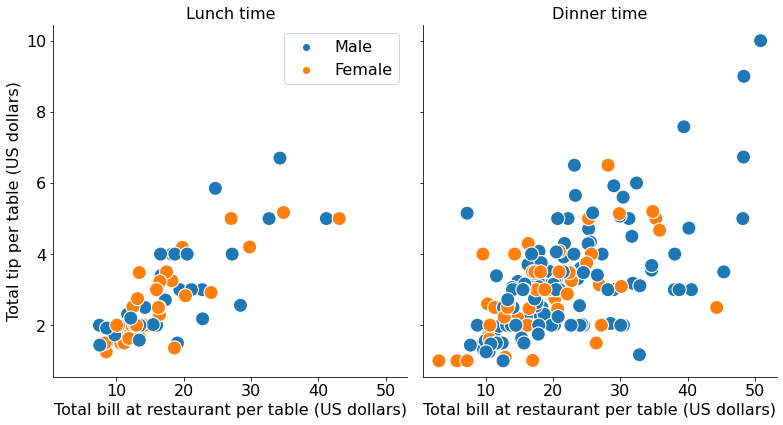

```python
g=sns.relplot(
data=df,
x="total_bill",
y="tip",
hue="sex",
col="time",
s=200,
)

#NOTICE THAT <class 'seaborn.axisgrid.FacetGrid'> OBJECT HAS ATTRIBUTES CONTAINING MPL OBJECTS
print('-----TYPES-----')
print(type(g.fig))
print(type(g.axes[0,0]))
print(type(g.axes[0,1]))

# BY ACCESSING THE MPL AXES/FIG ATTRIBUTES, WE CAN USE ALL OF OUR FAMILIAR MPL COMMANDS TO CUSTOMIZE

FS=16

#FIGURE TITLE
g.fig.set_size_inches(12, 6)

#AXIS LABELS AND FONT SIZE
g.axes[0,0].set_xlabel('Total bill at restaurant per table (US dollars)', fontsize=FS)
g.axes[0,0].set_ylabel('Total tip per table (US dollars)', fontsize=FS)

g.axes[0,1].set_xlabel('Total bill at restaurant per table (US dollars)', fontsize=FS)

#AXIS TIC FONT SIZE
for i in range(0,2):
    g.axes[0,i].tick_params(axis='both', which='major', labelsize=FS)
    #g.axes[0,i].tick_params(axis='both', which='minor', labelsize=FS)

#TITLE FONT SIZE
g.axes[0,0].set_title("Lunch time",fontsize=FS)
g.axes[0,1].set_title("Dinner time",fontsize=FS)

#LEGEND FONT SIZE
g.axes[0,0].legend(fontsize=FS)

#REMOVE SIDE LEGEND
g._legend.remove()
```

### Styles and color palettes

Seaborn includes various styles and color palettes for modifying the aesthetic of the plot.

The styles variable takes on four values; `whitegrid`, `darkgrid`, `dark`, and `white`.

The color palettes are the same as MPL, a description of them can be found at the following links

- https://matplotlib.org/3.5.0/tutorials/colors/colormaps.html
- https://seaborn.pydata.org/tutorial/color_palettes.html

The style and color palette can be modified individually using the following commands

- `sns.set_palette()`
- `sns.set_style()`

Or at the same time using the `sns.set_theme()` command, as shown in the following examples.

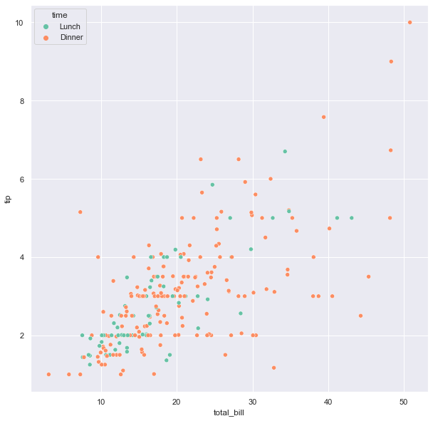

```python
sns.set_theme(style='darkgrid', palette="Set2")
sns.scatterplot(data=df, x="total_bill", y="tip", hue="time")
```

As mentioned above, the style and color palette can also be set individually, as in the following example.

As we can see, the result is identical to the previous example.

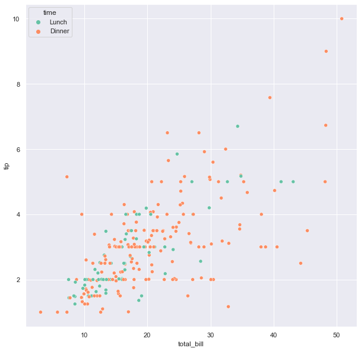

```python
sns.set_palette(palette="Set2")
sns.set_style("darkgrid")
sns.scatterplot(data=df, x="total_bill", y="tip", hue="time")
```

In the following examples, we explore the various styles along with different color palettes.

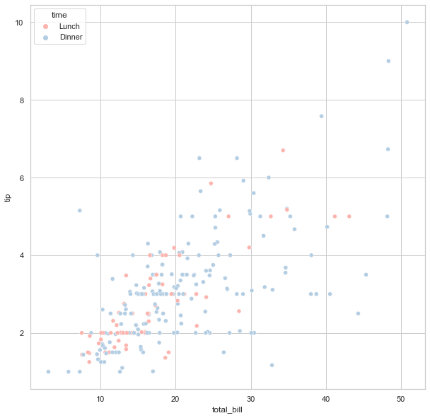

```python
sns.set_theme(style='whitegrid', palette="Pastel1")
sns.scatterplot(data=df, x="total_bill", y="tip", hue="time")
```

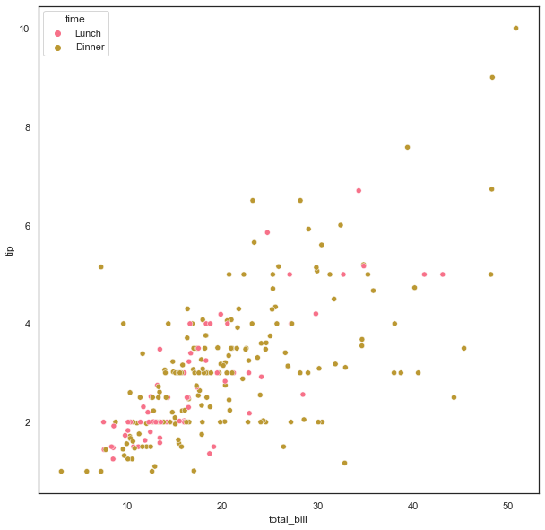

```python
sns.set_theme(style='white', palette="husl")
sns.scatterplot(data=df, x="total_bill", y="tip", hue="time")
```

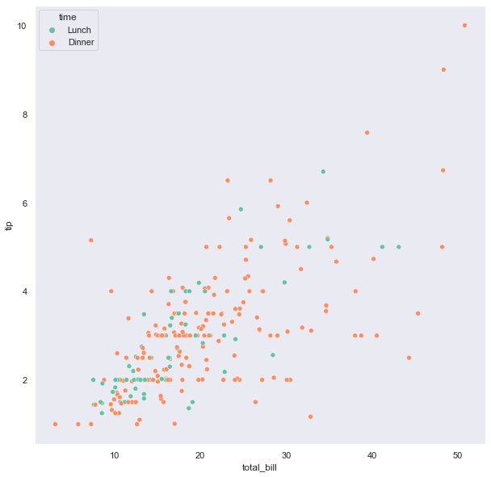

```python
sns.set_theme(style='dark', palette="Set2")
sns.scatterplot(data=df, x="total_bill", y="tip", hue="time")
```